# Sherryx_OriginalHomeworkCode_03

Sherry Xie

2025-02-25

## Set up

```r
#download the new package ggpubr first
#install.packages("ggpubr") for Q-Q plots

#loading ggplot for the figures
library(ggplot2)
library(dplyr)
library(ggpubr)
```

```r
#loading prettydoc for the theme
#library(prettydoc)
```

## Favorite picture related to zombies that I was able to find online (credit to reddit)

[figure not shown]

## 5 Challenges I have faced

1. **Communication with Group Members**: I had a hard time coordinating with my groupmates because they were unresponsive to my Slack messages and emails. This made it difficult to clarify questions and ensure we were all on the same page. One group member finally sent me her repository, but it was late Sunday night, leaving me little time to review her work or provide meaningful feedback. This last-minute sharing also made it harder to incorporate any potential revisions before the deadline.
2. **Understanding Factors vs. Data Frames:** One of the biggest technical challenges I faced was knowing when to convert factors into numerical values for analysis. At times, I didn’t realize that a variable was stored as a factor, which led to errors when trying to perform calculations. Other times, I converted a factor into numbers but didn’t check whether R had assigned meaningful numerical values or just default categorical codes. This made me second-guess how I was handling data and whether I was processing it correctly for statistical analysis.
3. **Difficulty Finding Information from Previous Modules:** Since this assignment required integrating multiple concepts we’ve covered in previous modules, I found myself constantly going back to old notes and materials. However, I wasted a lot of time searching for specific details because I didn’t have an organized way to reference them. I realized that I need to create a dedicated document that summarizes key functions, common troubleshooting solutions, and essential concepts from each module. Having a centralized resource would make reviewing past material much more efficient and help me work through assignments faster.
4. **Increased Errors and Self-Doubt in Coding:** Compared to previous assignments, I found myself getting stuck much more frequently. Small errors, like typos or forgetting a specific function syntax, caused frustrating error messages that were difficult to debug on my own. Since this assignment involved statistical concepts on top of R coding, I struggled to piece together different elements correctly. The frequent setbacks made me doubt my ability to code effectively, and I found myself questioning whether I was really improving in R. The fact that stats build upon so many previous modules made troubleshooting even harder, as a mistake from an earlier step could throw off the entire analysis.
5. **Time Management and Workflow Balance:** Last time, I decided to finish all the modules before starting the homework, thinking it would help me troubleshoot less on my own. However, this time, I spent so much time working through the modules that I didn’t leave myself enough time to complete the assignment properly. I felt rushed while finishing the homework and didn’t have enough time to double-check my work or debug issues carefully. I need to adjust my time allocation so that I can still review the modules while ensuring I have enough time to apply the concepts and complete the assignment at a comfortable pace.

## Load zombie. csv

```r
#loading the initial zombie csv from prof. schimt's repo
zombie <- read.csv("/Users/sherryxie/CODE/Github/repos/Homework/Sherry's Homework 03/zombies.csv")

#trying to visually understanding the data before I do anything to it
str(zombie)
```

```
## 'data.frame':    1000 obs. of  10 variables:
##  $ id                : int  1 2 3 4 5 6 7 8 9 10 ...
##  $ first_name        : chr  "Sarah" "Mark" "Brandon" "Roger" ...
##  $ last_name         : chr  "Little" "Duncan" "Perez" "Coleman" ...
##  $ gender            : chr  "Female" "Male" "Male" "Male" ...
##  $ height            : num  62.9 67.8 72.1 66.8 64.7 ...
##  $ weight            : num  132 146 153 130 132 ...
##  $ zombies_killed    : int  2 5 1 5 4 1 0 4 9 2 ...
##  $ years_of_education: int  1 3 1 6 3 4 4 0 3 3 ...
##  $ major             : chr  "medicine/nursing" "criminal justice administration" "education" "energy studies" ...
##  $ age               : num  17.6 22.6 21.9 18.2 21.1 ...
```

## 1. Population mean and standard deviation ERROR

```r
# Function for population mean and standard deviation since we can not use build in sd and var
#population_stats <- function(zombie) {
  #mean <- mean(zombie, na.rm = TRUE)       # Population mean from the zombie csv
  #sd <- sqrt(sum((x - mu)^2) / length(x))  # Population standard deviation (N, not N-1)
  #return(c(Mean = mean, SD = sd))
#}

# Select relevant quantitative variables
#quantitative_variables <- zombie %>% select(height, weight, age, zombies_killed, years_of_education)

# Apply the function to each quantitative column listed in hw instruction
# ERROR MESSAGE HERE
#population_stats_results <- sapply(quantitative_variables, population_stats)

#print(population_stats_results)
```

## 2. Boxplot for each quantitative variable by gender

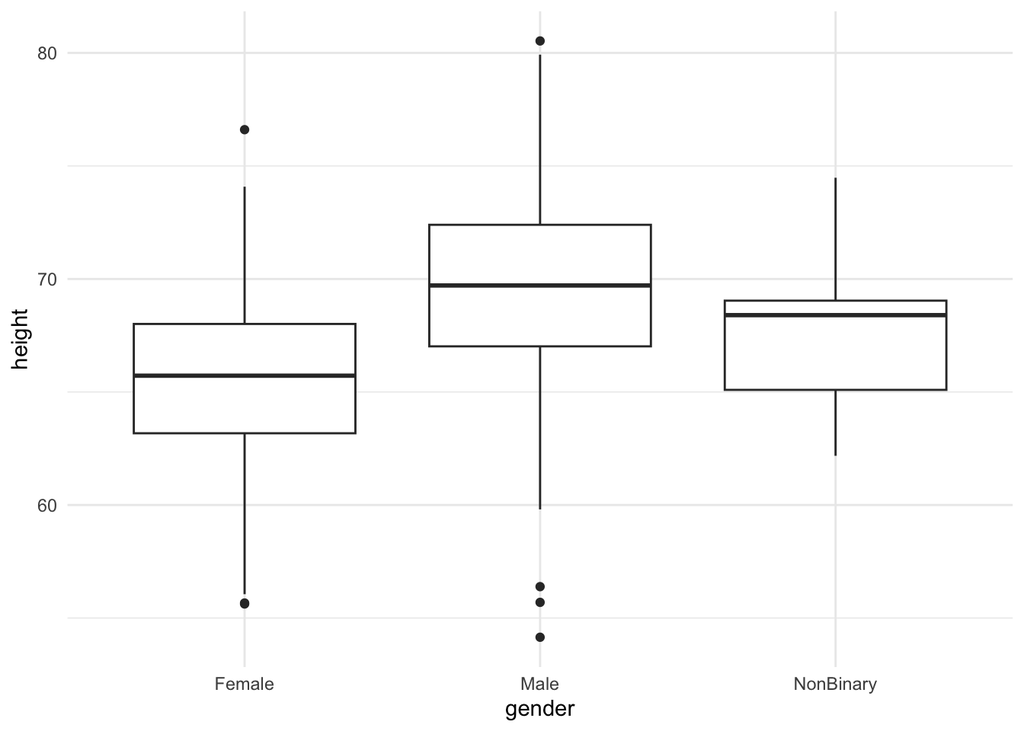

```r
# Convert gender to a factor just in case it is not already
zombie$gender <- as.factor(zombie$gender)

# Boxplot for each quantitative variable by gender
ggplot(zombie, aes(x = gender, y = height)) + geom_boxplot() + theme_minimal()
```

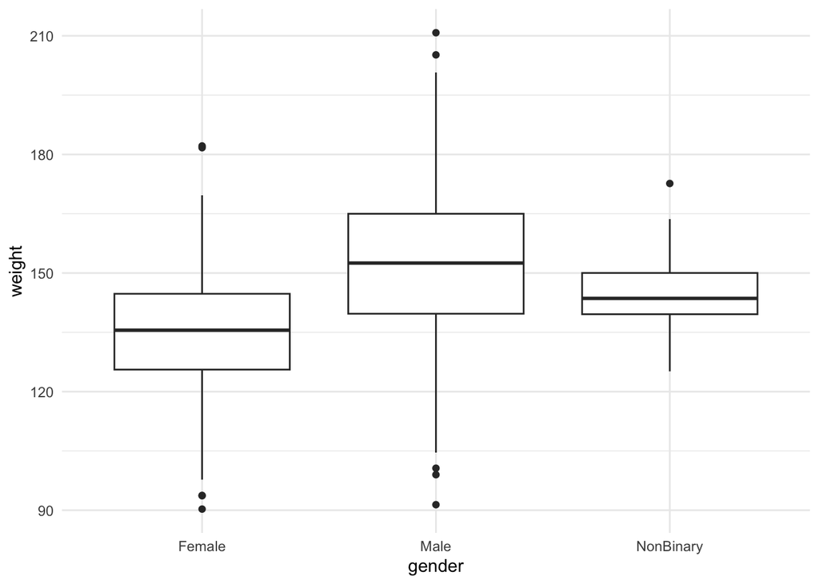

```r
ggplot(zombie, aes(x = gender, y = weight)) + geom_boxplot() + theme_minimal()
```

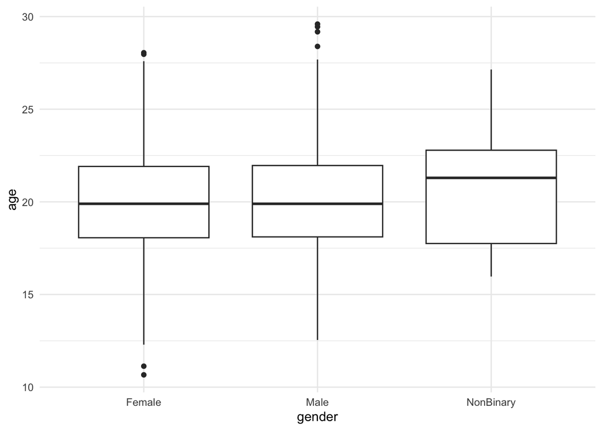

```r
ggplot(zombie, aes(x = gender, y = age)) + geom_boxplot() + theme_minimal()
```

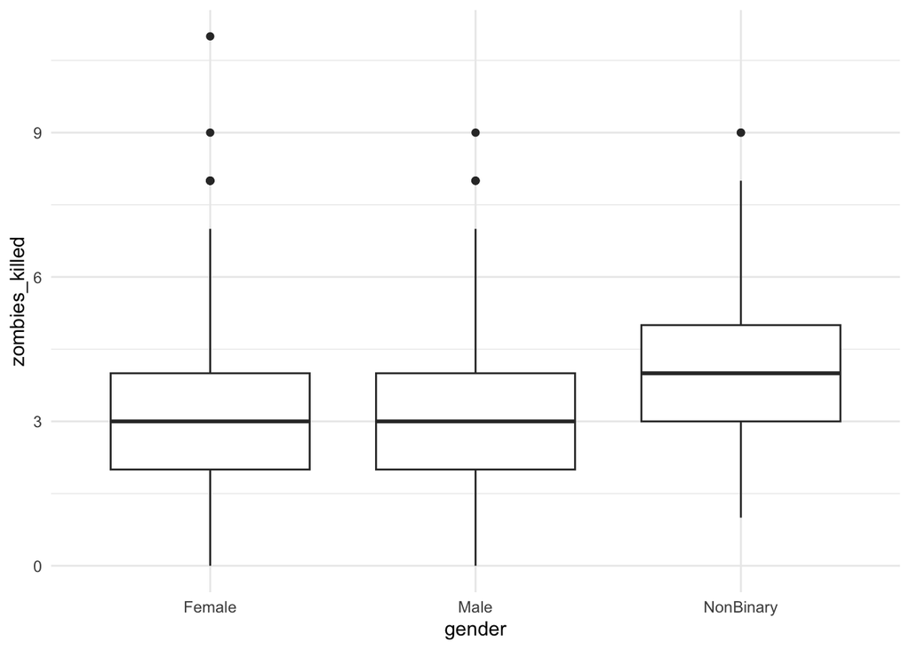

```r
ggplot(zombie, aes(x = gender, y = zombies_killed)) + geom_boxplot() + theme_minimal()
```

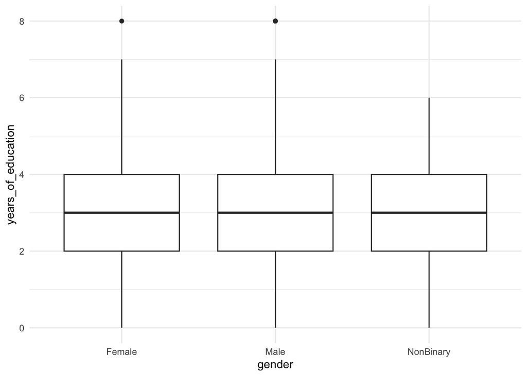

```r
ggplot(zombie, aes(x = gender, y = years_of_education)) + geom_boxplot() + theme_minimal()
```

## 3. Scatterplots of height and weight in relation to age

From the two plots, I think the two variables height and weight are related because the line of best fit from both scatter plots are linearly upward trend.

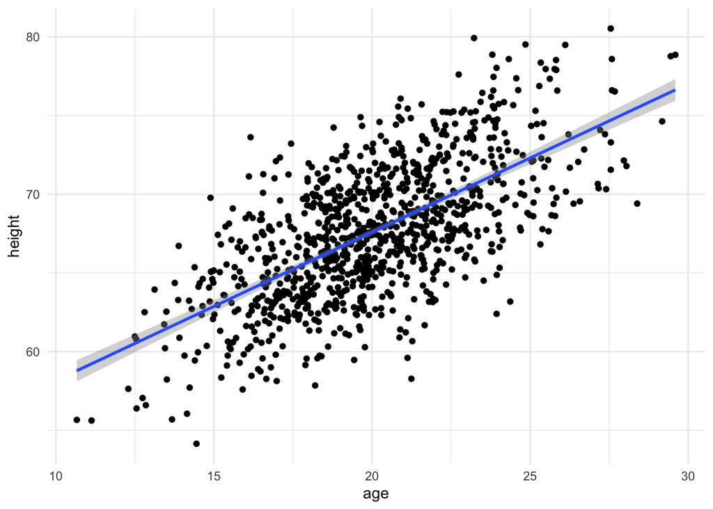

```r
#age vs height scatterplot
# I added in a line of best fit to better help me see if the two terms are related with each other
ggplot(zombie, aes(x = age, y = height)) + geom_point() + geom_smooth(method = "lm") + theme_minimal()
```

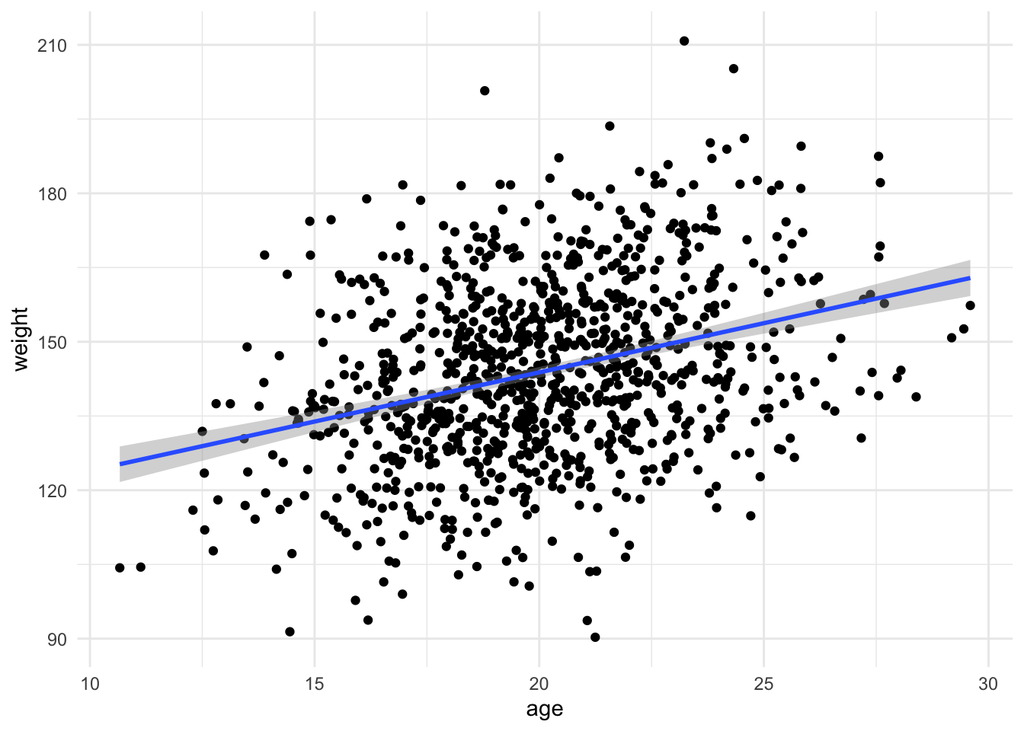

```r
#age vs weight scatterplot
# I added in a line of best fit to better help me see if the two terms are related with each other
ggplot(zombie, aes(x = age, y = weight)) + geom_point() + geom_smooth(method = "lm") + theme_minimal()
```

## 4. Histograms and Q-Q plots

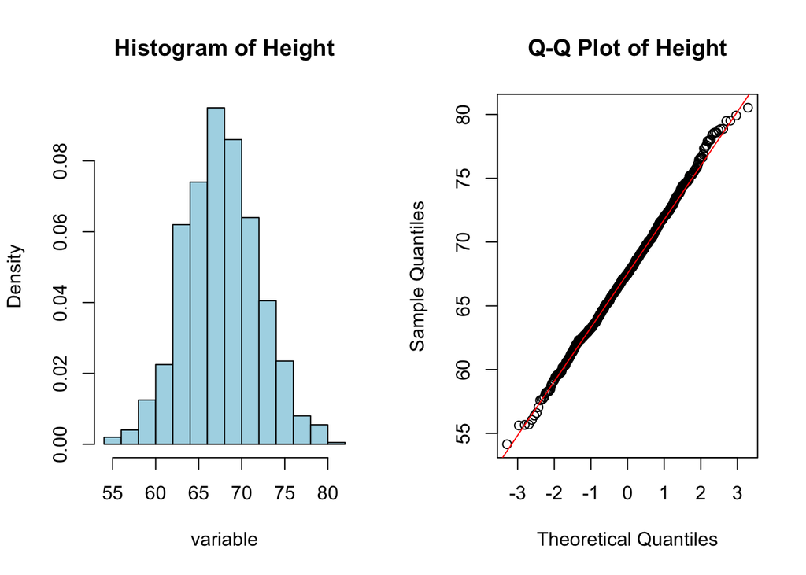

```r
# Function to plot histogram & Q-Q plot so I do not have to write it out for each of the variables
normal_distribution_check <- function(variable, name) {
  par(mfrow = c(1, 2))  # Side-by-side plots histogram vs pplot comparision
  hist(variable, main = paste("Histogram of", name), col = "lightblue", probability = TRUE) #histogram view
  qqnorm(variable, main = paste("Q-Q Plot of", name)) #qqplot view
  qqline(variable, col = "red")                       #qqplot linear diagonal line
}

# Apply to each variable
normal_distribution_check(zombie$height, "Height")        #height comparision
```

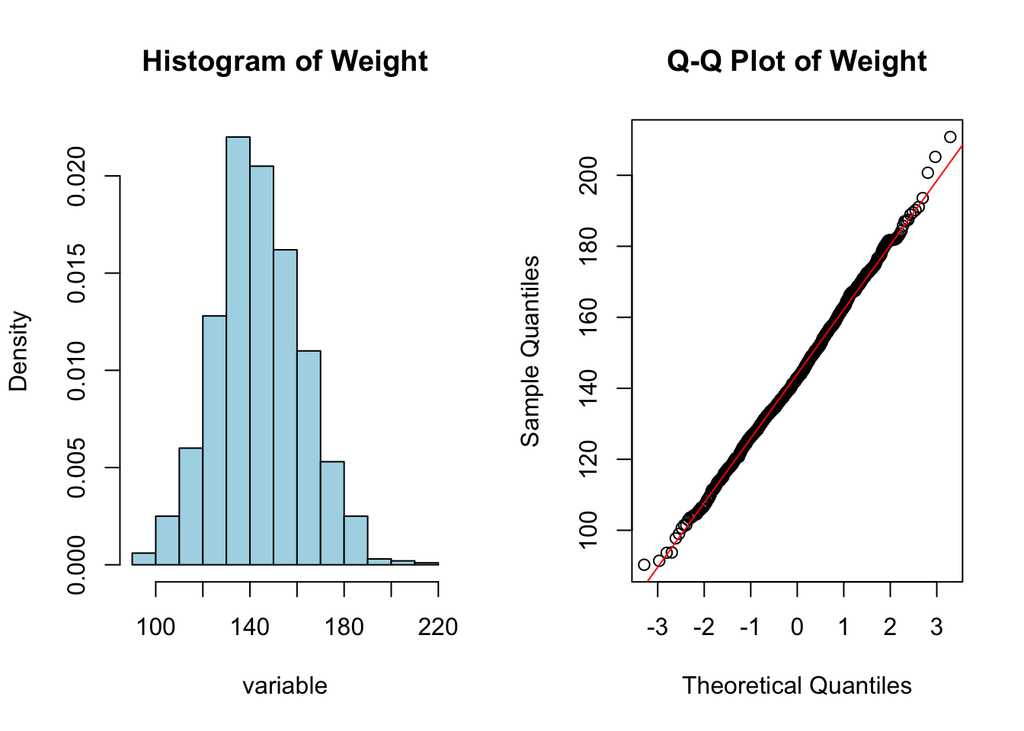

```r
normal_distribution_check(zombie$weight, "Weight")       #weight comparision
```

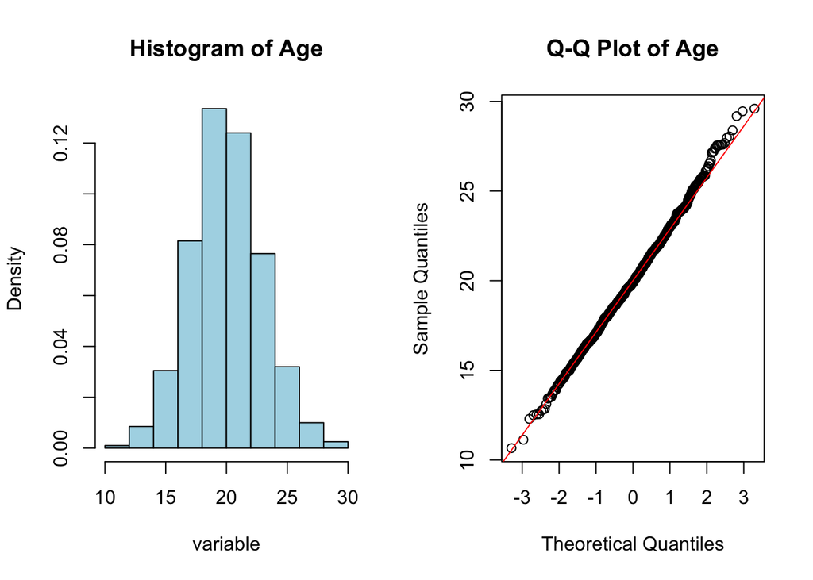

```r
normal_distribution_check(zombie$age, "Age")             #age comparision
```

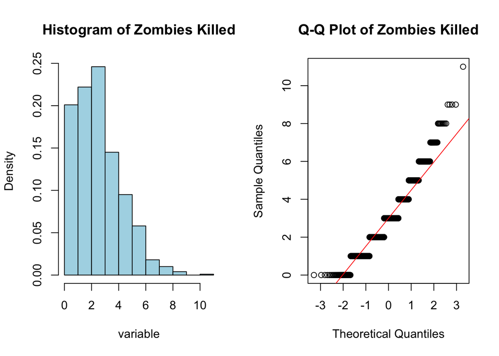

```r
normal_distribution_check(zombie$zombies_killed, "Zombies Killed")       #zombies killed comparision
```

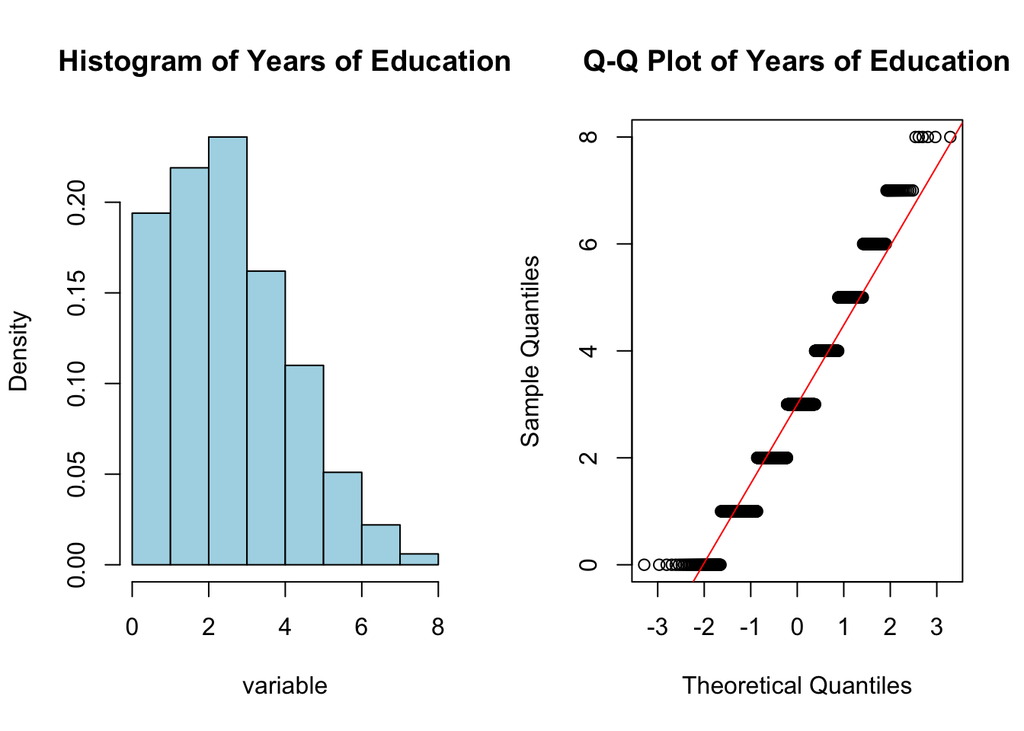

```r
normal_distribution_check(zombie$years_of_education, "Years of Education")   #years of education comparision
```

## 5. Pt:1 Random Sample of 30 & Calculate Summary Statistics

```r
set.seed(100)  # For reproducibility

# Sample 30 survivors without replacement
sample_30 <- zombie %>% sample_n(30)

# Compute sample mean, sample SD, and standard error
#I used the built in version compared to question one because no we are looking at a sample
sample_stats <- sample_30 %>% summarise(
  Mean_Height = mean(height, na.rm = TRUE),
  SD_Height = sd(height, na.rm = TRUE),
  SE_Height = SD_Height / sqrt(30),

  Mean_Weight = mean(weight, na.rm = TRUE),
  SD_Weight = sd(weight, na.rm = TRUE),
  SE_Weight = SD_Weight / sqrt(30),

  Mean_Age = mean(age, na.rm = TRUE),
  SD_Age = sd(age, na.rm = TRUE),
  SE_Age = SD_Age / sqrt(30),

  Mean_ZombiesKilled = mean(zombies_killed, na.rm = TRUE),
  SD_ZombiesKilled = sd(zombies_killed, na.rm = TRUE),
  SE_ZombiesKilled = SD_ZombiesKilled / sqrt(30),

  Mean_Education = mean(years_of_education, na.rm = TRUE),
  SD_Education = sd(years_of_education, na.rm = TRUE),
  SE_Education = SD_Education / sqrt(30)
)

print(sample_stats)
```

```
##   Mean_Height SD_Height SE_Height Mean_Weight SD_Weight SE_Weight Mean_Age
## 1    67.85552  4.794839 0.8754138     146.721  19.63913  3.585598 19.80089
##     SD_Age    SE_Age Mean_ZombiesKilled SD_ZombiesKilled SE_ZombiesKilled
## 1 2.713933 0.4954941           2.266667         1.362891        0.2488287
##   Mean_Education SD_Education SE_Education
## 1            3.2      1.47157    0.2686706
```

## 5. Pt 2: 95% CI

```r
# Function to calculate 95% Confidence Interval
calc_CI <- function(mean, se, n) {
  error_margin <- qt(0.975, df = n - 1) * se
  lower <- mean - error_margin
  upper <- mean + error_margin
  return(c(lower, upper))  # Returns a vector of length 2
}

#Listing out the CI for all the variables
sample_stats <- sample_stats %>%
  mutate(
    CI_Height_Lower = Mean_Height - qt(0.975, df = 30-1) * SE_Height,
    CI_Height_Upper = Mean_Height + qt(0.975, df = 30-1) * SE_Height,
    CI_Weight_Lower = Mean_Weight - qt(0.975, df = 30-1) * SE_Weight,
    CI_Weight_Upper = Mean_Weight + qt(0.975, df = 30-1) * SE_Weight,
    CI_Age_Lower = Mean_Age - qt(0.975, df = 30-1) * SE_Age,
    CI_Age_Upper = Mean_Age + qt(0.975, df = 30-1) * SE_Age
  )

# Print results
print(sample_stats)
```

```
##   Mean_Height SD_Height SE_Height Mean_Weight SD_Weight SE_Weight Mean_Age
## 1    67.85552  4.794839 0.8754138     146.721  19.63913  3.585598 19.80089
##     SD_Age    SE_Age Mean_ZombiesKilled SD_ZombiesKilled SE_ZombiesKilled
## 1 2.713933 0.4954941           2.266667         1.362891        0.2488287
##   Mean_Education SD_Education SE_Education CI_Height_Lower CI_Height_Upper
## 1            3.2      1.47157    0.2686706         66.0651        69.64595
##   CI_Weight_Lower CI_Weight_Upper CI_Age_Lower CI_Age_Upper
## 1        139.3877        154.0544     18.78749     20.81429
```

```r
set.seed(100) #set for reproducibility

# Function to sample and compute means
sample_means <- function() {
  sample_100 <- zombie %>% sample_n(30)
  return(c(
    mean(sample_100$height, na.rm = TRUE),
    mean(sample_100$weight, na.rm = TRUE),
    mean(sample_100$age, na.rm = TRUE),
    mean(sample_100$zombies_killed, na.rm = TRUE),
    mean(sample_100$years_of_education, na.rm = TRUE)
  ))
}

# Repeat 99 times
sampling_99 <- replicate(99, sample_means())

# Convert to data frame
sampling_df <- as.data.frame(t(sampling_99))
colnames(sampling_df) <- c("Height", "Weight", "Age", "ZombiesKilled", "YearsEducation")

# Calculate mean & SD of sampling distribution
sampling_summary <- sampling_df %>% summarise_all(list(Mean = mean, SD = sd))
print(sampling_summary)
```

```
##   Height_Mean Weight_Mean Age_Mean ZombiesKilled_Mean YearsEducation_Mean
## 1    67.70304    144.1777 20.06193           3.001347            2.934007
##   Height_SD Weight_SD   Age_SD ZombiesKilled_SD YearsEducation_SD
## 1 0.7199136  3.161344 0.472303        0.3242965         0.2847595
```

## 6. Pt:2 Normally distributed visualization

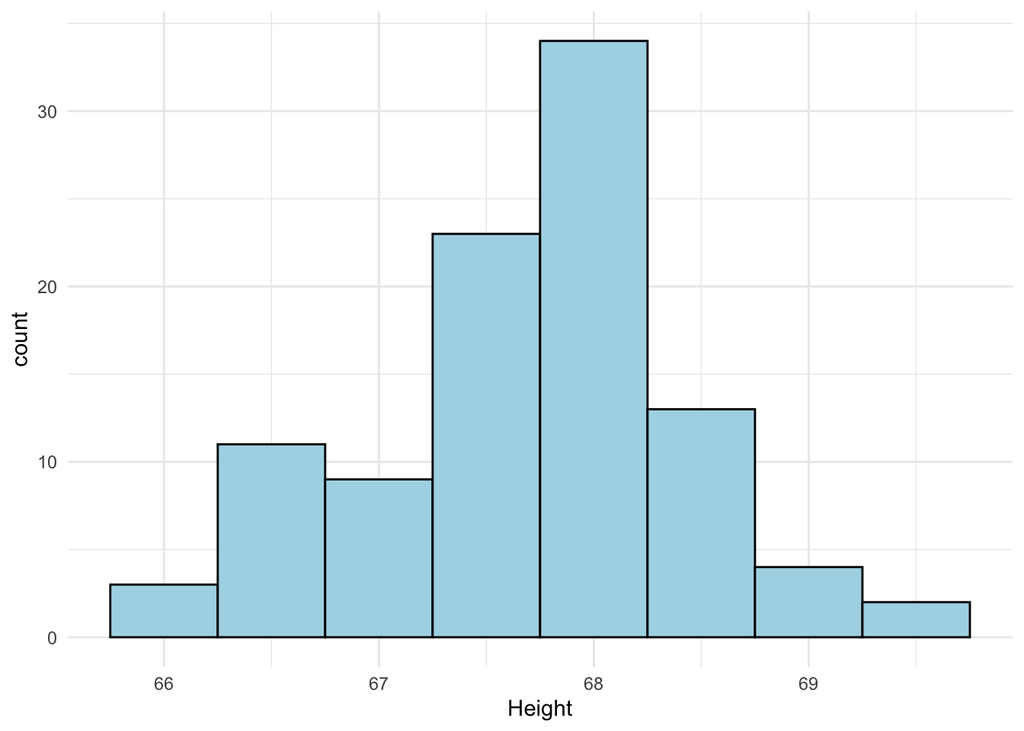

```r
# Histograms for sampling distributions
ggplot(sampling_df, aes(x = Height)) + geom_histogram(binwidth = 0.5, fill = "lightblue", color = "black") + theme_minimal()
```

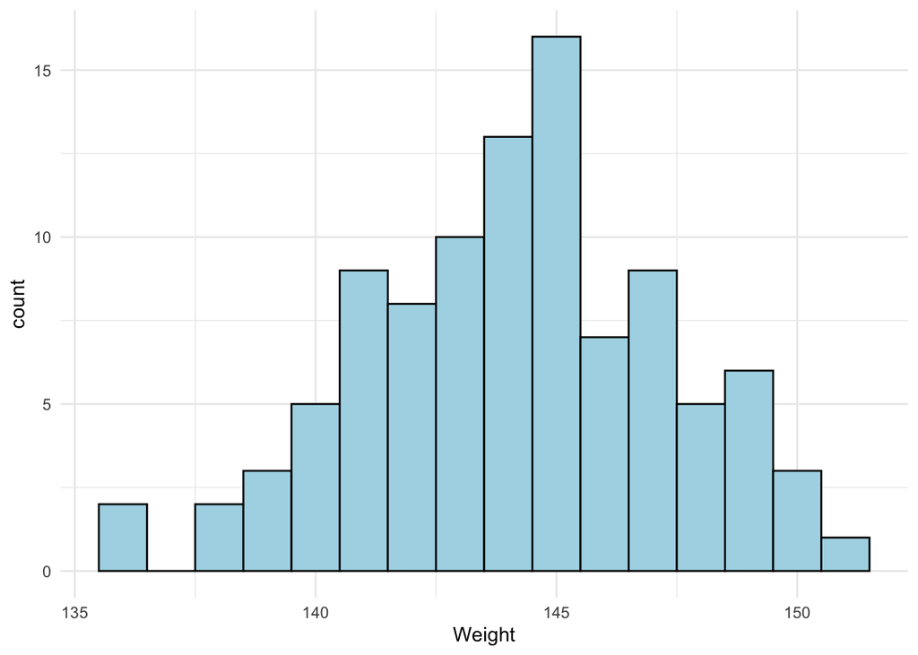

```r
ggplot(sampling_df, aes(x = Weight)) + geom_histogram(binwidth = 1, fill = "lightblue", color = "black") + theme_minimal()
```

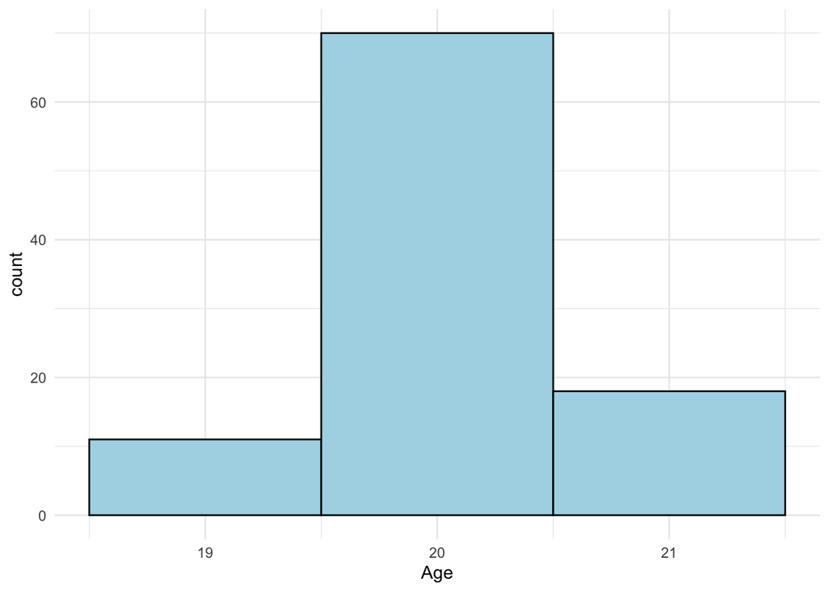

```r
ggplot(sampling_df, aes(x = Age)) + geom_histogram(binwidth = 1, fill = "lightblue", color = "black") + theme_minimal()
```

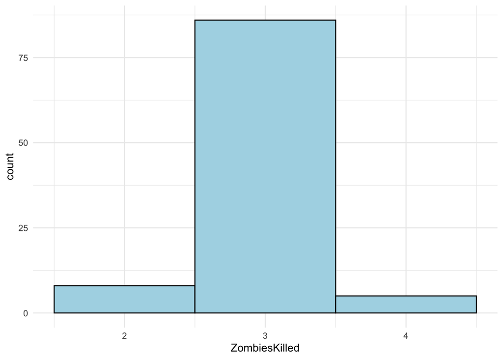

```r
ggplot(sampling_df, aes(x = ZombiesKilled)) + geom_histogram(binwidth = 1, fill = "lightblue", color = "black") + theme_minimal()
```

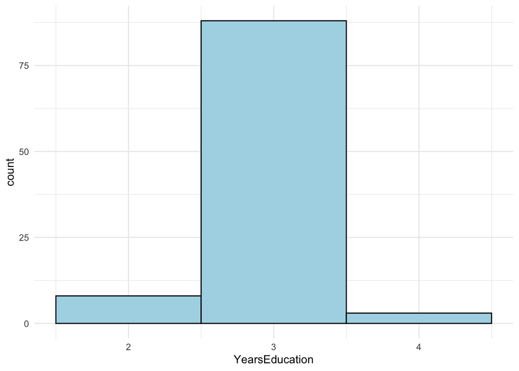

```r
ggplot(sampling_df, aes(x = YearsEducation)) + geom_histogram(binwidth = 1, fill = "lightblue", color = "black") + theme_minimal()
```